# presentation

## Od odhadu k nejistotě

Biostatistika

[👤](https://ondrejmottl.github.io/) Ondřej Mottl

[Moodle](https://dl2.cuni.cz/course/view.php?id=106)

## Gejzír Old Faithful v číslech

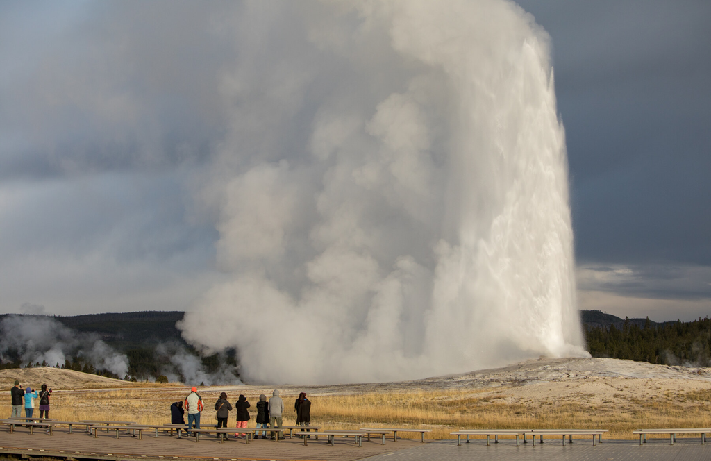

Data z léta 2024

Foto: [NPS/Jim Peaco](https://www.nps.gov/media/photo/view.htm?id=9C858B86-9CDB-4BB0-8C17-EA567391FAA2), public domain. Údaje: GeyserTimes a National Park Service.

## Pomůže délka erupce předpovědět další čekání?

Gejzír Old Faithful právě ukončil erupci.

**Pomůže její délka odhadnout, za jak dlouho začne další?**

ANO

Délka erupce nám pomůže.

NE

Délka erupce nám nepomůže.

Když nehlasujeme: vyberte **ANO**, nebo **NE** a připravte jednu větu na obhajobu.

## Výsledky učení

Po dnešní přednášce budete schopni:

- vysvětlit, proč jiný soubor pozorování může dát jiný odhad sklonu
- rozlišit velikost vztahu od přesnosti odhadu
- interpretovat 95% interval spolehlivosti
- zapsat výsledek s odhadem, SE, CI a jednotkami

## Co už umíme z předchozí lekce?

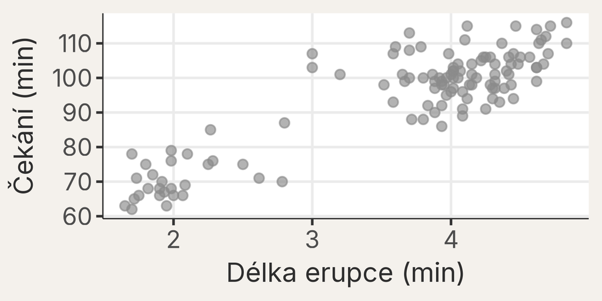

Se sousedem: popište směr vztahu a jednu věc, kterou z bodů zatím nevíme.

## Lineární model

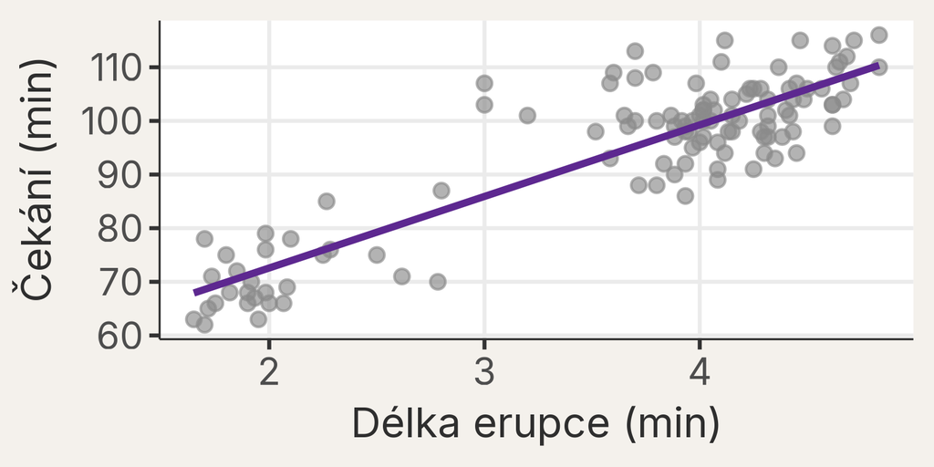

Fialová přímka shrnuje vztah v **tomto souboru pozorování**.

**Stejná data + stejný modelový vzorec = vždy stejné odhady.** Funkce `lm()` zde nic náhodně nelosuje.

## Dostali bychom příště stejnou přímku?

Představte si, že gejzír pozoruje někdo jiný v jiných intervalech.

Budou jeho body — a jeho sklon — úplně stejné?

Když nehlasujeme: napište si „ano“ nebo „ne“ a jednu větu, kterou svou volbu obhájíte.

## Pepa pozoroval pouze červen

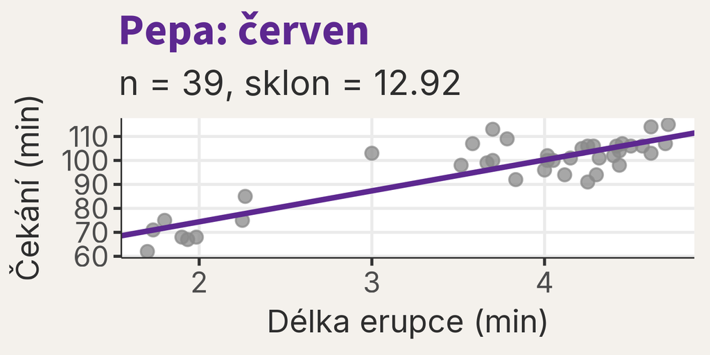

Erupce delší o jednu minutu souvisela v Pepových datech s čekáním delším přibližně o **12.92 minuty**.

## Co čekáte od Mařenky a Karla?

Diskuze se sousedem — 2 min

Mařenka pozoruje v červenci, Karel v srpnu.

**Budou všechny tři sklony stejné? Proč ano/ne?**

## Stejný postup, tři různé výsledky

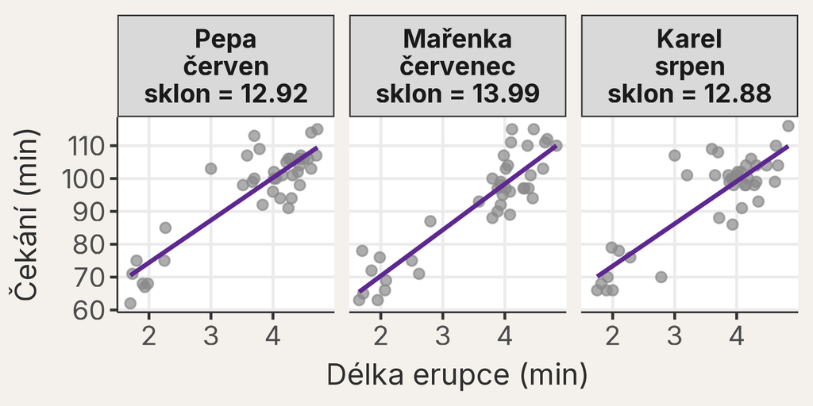

## Odhad není oddělený od dat

Co zůstalo stejné

- otázka;
- proměnné;
- lineární model;
- postup fitování.

Co se změnilo

- pozorované erupce;
- poloha bodů;
- odhadnutá přímka;
- sklon.

Proměnlivosti odhadu mezi možnými výběry říkáme výběrová variabilita.

## Co udělá sto dalších pozorovatelů?

Každý pošle 40 erupcí, fituje stejný model a získá jeden sklon.

Jak budou vypadat všechny sklony společně?

Ve dvojici nakreslete velmi hrubý tvar, který očekáváte po 100 hlášeních.

## Sledujte cestu jednoho sklonu

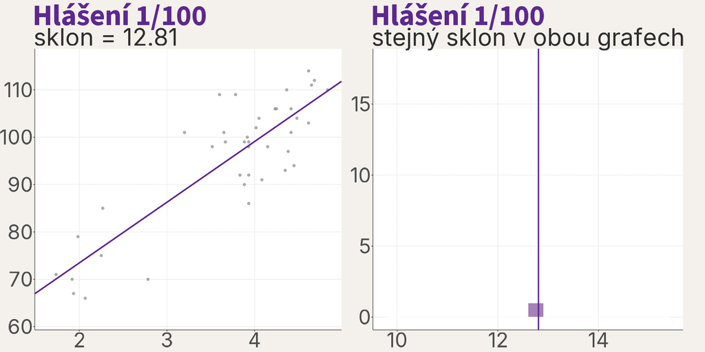

Sledujte: nový soubor bodů → nová přímka → nový sklon → další část histogramu.

## Po 100 hlášeních

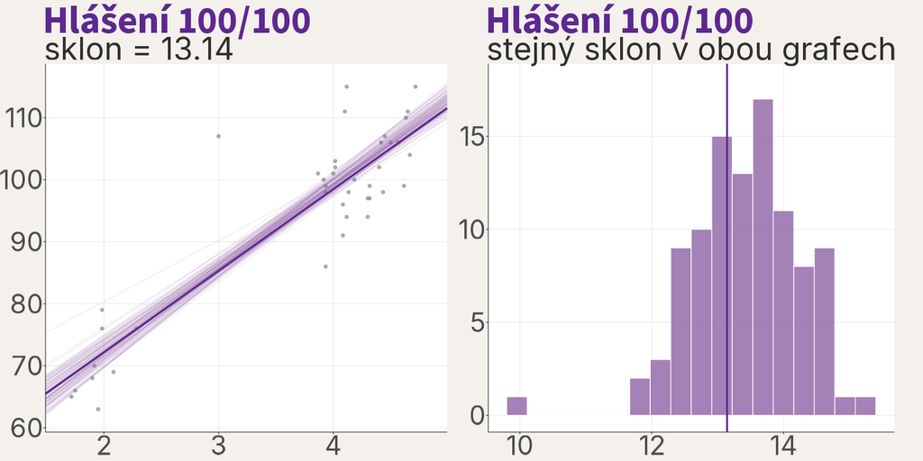

## Co vidíme — a co ještě nevíme?

Co vidíme

- sklony nejsou stejné;
- většina leží ve společné oblasti;
- některé výběry dávají strmější či plošší přímku.

Co ještě nevíme

- jak proměnlivost popsat jedním číslem;
- jak přesný je odhad z našich dat;
- jaký rozsah efektů je s daty slučitelný.

## Kde R ukrývá velikost a přesnost?

Hledání ve výstupu — dvojice

Najděte dvě čísla:

1. které popisuje **velikost vztahu**;
2. které popisuje **přesnost tohoto odhadu**.

## Najděte řádek sklonu

```r
mod_gejzir <-
  lm(
    formula = cekani_min ~ delka_erupce_min,
    data = data_gejzir
  )

summary(mod_gejzir)
```

```
Call:
lm(formula = cekani_min ~ delka_erupce_min, data = data_gejzir)

Residuals:
     Min       1Q   Median       3Q      Max
-13.0280  -4.4756  -0.3648   3.6354  21.0827

Coefficients:
                 Estimate Std. Error t value Pr(>|t|)
(Intercept)       45.9122     2.4658   18.62   <2e-16 ***
delka_erupce_min  13.3350     0.6575   20.28   <2e-16 ***
---
Signif. codes:  0 '***' 0.001 '**' 0.01 '*' 0.05 '.' 0.1 ' ' 1

Residual standard error: 6.833 on 115 degrees of freedom
Multiple R-squared:  0.7815,    Adjusted R-squared:  0.7796
F-statistic: 411.4 on 1 and 115 DF,  p-value: < 2.2e-16
```

Řádek

`delka_erupce_min` = **sklon**

Odhad (Estimate)

**13.34** min čekání / min erupce

Standardní chyba (Std. Error)

**0.66** min čekání / min erupce

## Velikost vztahu nebo přesnost?

„O kolik minut se změní čekání?“

Velikost vztahu

„Jak moc by se odhad měnil mezi výběry?“

Přesnost odhadu

„Je vztah prudký, nebo pozvolný?“

Velikost vztahu

„Jak těsně se možné odhady shlukují?“

Přesnost odhadu

Ve dvojici, přiřaďte věty

## Jedna standardní chyba jako měřítko

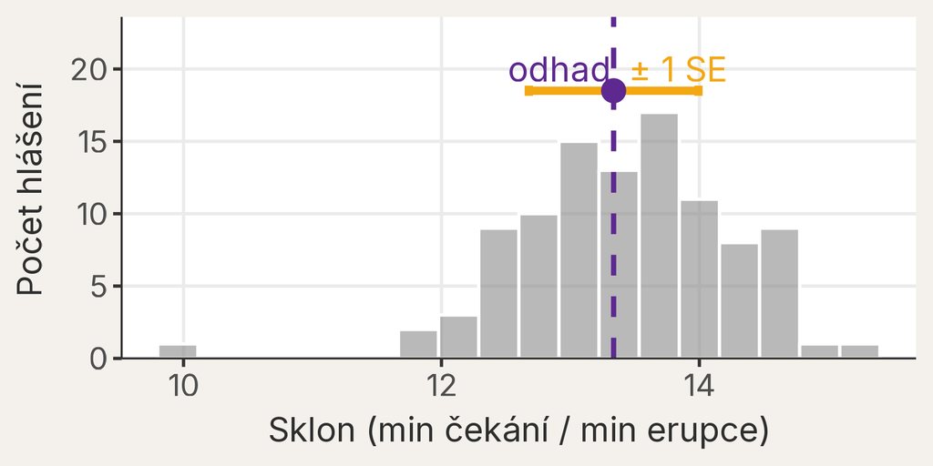

## Co ještě neplyne?

Rozsah **odhad ± jedna standardní chyba** není interval spolehlivosti.

Je to měřítko přesnosti, ze kterého teprve vytvoříme interval určený pro interpretaci nejistoty.

## Jak široký rozsah je slučitelný s daty?

Máme odhad a jeho standardní chybu.

Jak z nich vytvořit srozumitelný rozsah možných velikostí vztahu?

## 95% interval spolehlivosti

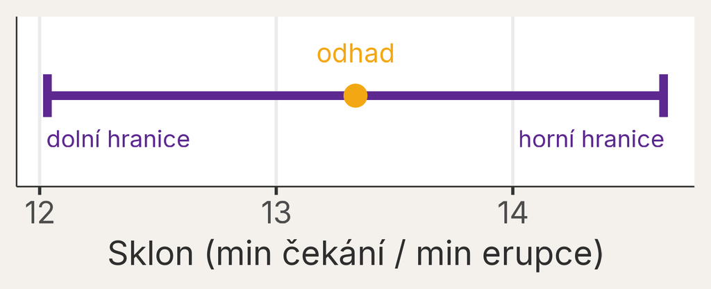

Pro gejzír Old Faithful: **[12.03; 14.64]** minuty čekání na minutu erupce.

## Co se stane při vyšší hladině?

Seřaďte intervaly od nejužšího

80 % · 90 % · 95 % · 99 %

Musí vyšší požadované pokrytí vést k užšímu, nebo širšímu intervalu?

Ve dvojici seřaďte čtyři hladiny a připravte jedno vysvětlení.

## Stejný odhad, různě široké intervaly

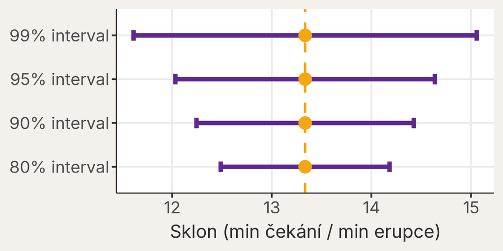

Čím častěji má postup zachytit skutečný sklon, tím širší musí být interval.

## Užší neznamená automaticky přesnější data

Intervaly porovnáváme jako přesnější a méně přesné pouze při stejné hladině spolehlivosti.

Snížením hladiny z 95 % na 80 % získáme užší interval, ale častěji mineme skutečný sklon. Z dat jsme nezískali více informace.

## Co znamená „95 %“?

A

95 % jednotlivých erupcí leží uvnitř intervalu.

B

Skutečný sklon má po výpočtu 95% pravděpodobnost být uvnitř.

C

Při mnoha opakováních pokryje skutečný sklon přibližně 95 % vytvořených intervalů.

Když nehlasujeme: zapište písmeno a podtrhněte slova, která rozhodla.

## 95 % patří k postupu

Správná odpověď

Při mnoha srovnatelných opakováních pokryje skutečný sklon přibližně 95 % takto vytvořených intervalů.

Neříkáme

- 95 % pozorování je uvnitř;
- tento interval má 95% šanci obsahovat pravdu;
- interval dokazuje určitou hodnotu.

## Statistická redakce: opravte titulek

Dvojice — 90 sekund

Redakce napsala:

> „Náš interval má 95% šanci obsahovat skutečný sklon.“

Přepište titulek do **jedné přesné věty o postupu**. Maximálně 15 slov.

## Sto pozorovatelů, sto 95% intervalů

Jako známý referenční sklon používáme odhad z modelu (**13.34**) a jeho SE (**0.66**).

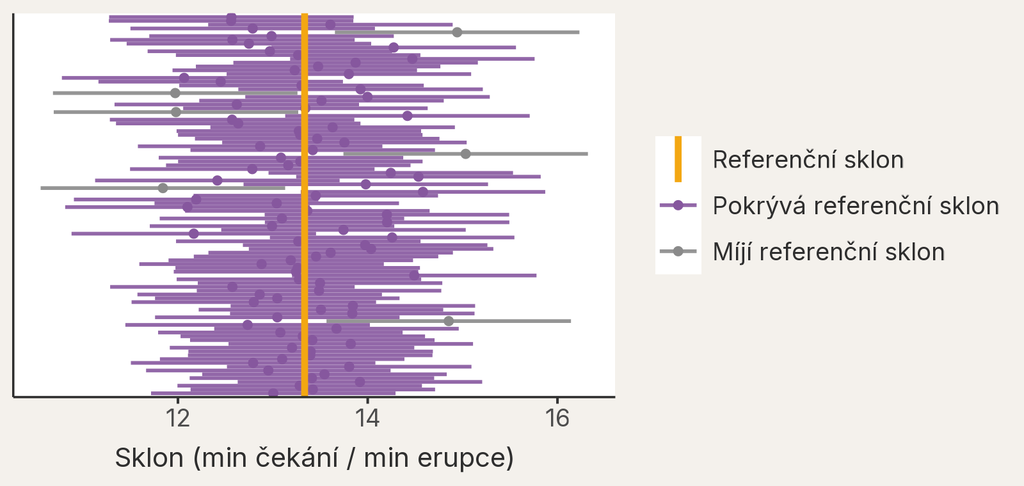

**94 ze 100** 95% intervalů pokrývá referenční sklon. V reálných datech skutečný populační sklon neznáme.

## Stejných sto pozorovatelů, 80% intervaly

**Co se stane s šířkou intervalů a počtem šedých intervalů?**

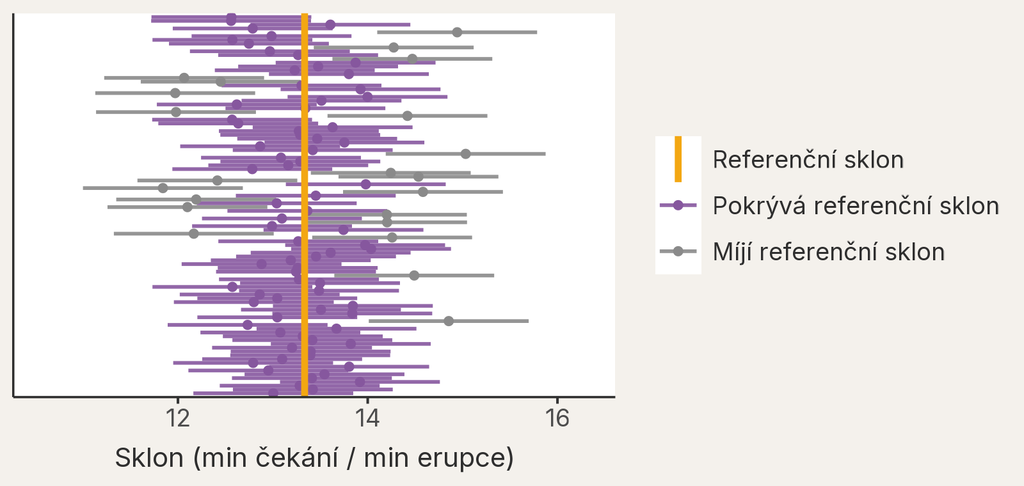

**78 ze 100** 80% intervalů pokrývá referenční sklon. Intervaly jsou užší a více z nich referenční sklon mine.

## Stejných sto pozorovatelů, 50% intervaly

**Kolik intervalů asi zasáhne oranžovou referenční čáru?**

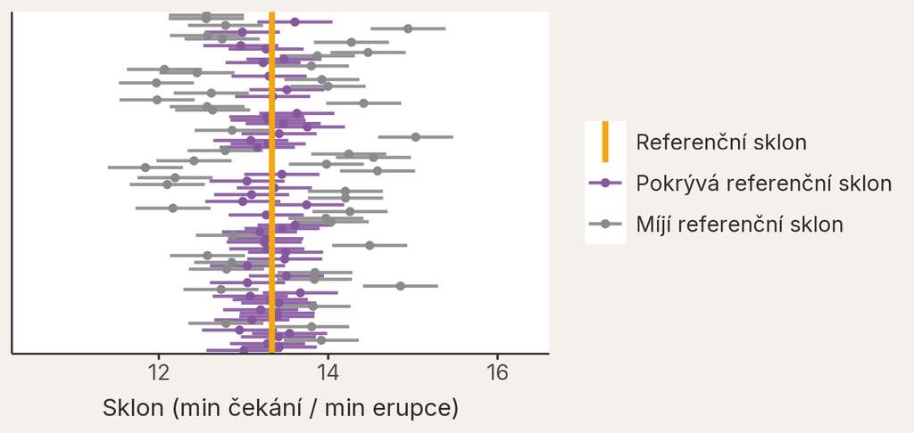

**50 ze 100** 50% intervalů pokrývá referenční sklon. Hladina popisuje úspěšnost postupu při opakování.

## Vraťme se k hlavní otázce

**Pomůže délka právě skončené erupce odhadnout, za jak dlouho začne další?**

Co už můžeme říct

Odhadli jsme velikost vztahu i rozsah efektů slučitelných s daty a modelem.

Co stále zůstává otevřené

Jak pomocí dat hodnotit konkrétní tvrzení o parametru modelu?

## Napište jednu vědeckou větu

Dvojice — 3 min

Vaše věta musí obsahovat:

- vztah mezi délkou erupce a čekáním;
- odhad sklonu;
- SE a 95% CI;
- jednotky;
- opatrný jazyk bez kauzálního tvrzení.

Data a výsledek modelu

Vyměňte si větu se sousední dvojicí: jsou v ní proměnné, jednotky a nejistota?

## Jedna možná věta

Erupce delší o jednu minutu souvisela s čekáním delším o **13.34 minuty** (odhad sklonu = 13.34, SE = 0.66, 95% CI [12.03, 14.64] minuty čekání na minutu erupce).

## Co ještě omezuje náš závěr?

Dobrovolníci nepozorovali dokonale náhodný výběr všech erupcí a blízké erupce mohou být časově propojené.

Výsledek je opatrný odhad vztahu v zachyceném procesu — ne neměnný přírodní zákon.

## Shrnutí

- Jiná pozorování mohou dát jiný odhad stejného vztahu.
- Odhad (`Estimate`) popisuje velikost vztahu; standardní chyba (`Std. Error`) přesnost odhadu.
- Interval spolehlivosti vyjadřuje rozsah efektů slučitelných s daty a modelem.
- Hodnota 95 % říká, jak často opakovaně vytvářený interval zachytí skutečný sklon.
- Vědecký závěr spojuje interpretaci, čísla, jednotky a omezení dat.

## Je vztah skutečný — a zobecnitelný?

Umíme popsat velikost efektu a jeho nejistotu.

Jak silné máme důkazy, že vztah není jen náhodným výsledkem tohoto výběru — a lze jej zobecnit?